# Lecture 4: Data Frames and Control Statement

### (Copied from R programming lecture notes, use for code reference only.)

## 1. Data Frames (continued)

### 1.1 Data frames: merge

- **Merging data frames is possible**
- **But we don’t often encounter two or more similar enough data frames that we can merge them easily.**
- **Usually we pick and choose columns from a number of data frames to build a new data frame.**
- **But this isn’t easy either since not all observations are from the same population.**
- **Always work with the minimum amount of data necessary for a given analysis**
- **There is no reason to create a big data frame if you are only going to be using 20 percent of the attributes/columns.**

#### One example: merge two data frames by a shared ID variable:

```r
df1 <- data.frame(indiv_id = 1:4, snp1 = c(1,1,0,1), snp2 = c(1,1,0,0))

df2 <- data.frame(indiv_id = c(1,3,4,6), cov1 = c(1.14,4.50,0.80,1.39),
                  cov2 = c(74.6,79.4,48.2,68.1))
df1
```

```
##   indiv_id snp1 snp2
## 1        1    1    1
## 2        2    1    1
## 3        3    0    0
## 4        4    1    0
```

```r
df2
```

```
##   indiv_id cov1 cov2
## 1        1 1.14 74.6
## 2        3 4.50 79.4
## 3        4 0.80 48.2
## 4        6 1.39 68.1
```

```r
merge(df1, df2, by="indiv_id")
```

```
##   indiv_id snp1 snp2 cov1 cov2
## 1        1    1    1 1.14 74.6
## 2        3    0    0 4.50 79.4
## 3        4    1    0 0.80 48.2
```

#### Specify which records you want to include by “all.x” and “all.y” arguments

```r
merge(df1, df2, by="indiv_id", all.x=T)
```

```
##   indiv_id snp1 snp2 cov1 cov2
## 1        1    1    1 1.14 74.6
## 2        2    1    1   NA   NA
## 3        3    0    0 4.50 79.4
## 4        4    1    0 0.80 48.2
```

```r
merge(df1, df2, by="indiv_id", all.y=T)
```

```
##   indiv_id snp1 snp2 cov1 cov2
## 1        1    1    1 1.14 74.6
## 2        3    0    0 4.50 79.4
## 3        4    1    0 0.80 48.2
## 4        6   NA   NA 1.39 68.1
```

```r
merge(df1, df2, by="indiv_id", all=TRUE)
```

```
##   indiv_id snp1 snp2 cov1 cov2
## 1        1    1    1 1.14 74.6
## 2        2    1    1   NA   NA
## 3        3    0    0 4.50 79.4
## 4        4    1    0 0.80 48.2
## 5        6   NA   NA 1.39 68.1
```

#### Note that the merge columns do not have to be named the same thing in each data frame as long as they refer to the same thing

```r
names(df2) <- c("id","cov1","cov2")
head(df1,2)
```

```
##   indiv_id snp1 snp2
## 1        1    1    1
## 2        2    1    1
```

```r
head(df2,2)
```

```
##   id cov1 cov2
## 1  1 1.14 74.6
## 2  3 4.50 79.4
```

```r
merge(df1,df2,by.x="indiv_id",by.y="id",all=TRUE)
```

```
##   indiv_id snp1 snp2 cov1 cov2
## 1        1    1    1 1.14 74.6
## 2        2    1    1   NA   NA
## 3        3    0    0 4.50 79.4
## 4        4    1    0 0.80 48.2
## 5        6   NA   NA 1.39 68.1
```

### 1.2 Data frames: split

#### The `split()` function lets us break up a data frame based on a grouping variable

#### For exapmle, we want to split up mtcars based on the number of cylinders which take on the values 4,6,8.

```r
# Without using split you could do:
eight.cyl <- mtcars[mtcars$cyl == 8,]
six.cyl <- mtcars[mtcars$cyl == 6, ]
four.cyl <- mtcars[mtcars$cyl == 4, ]
# But what if we had 10 categories we wanted to split by ?
```

#### Use the `split` command which gives back a list with each element containing a part of the data frame corresponding to each cylinder group.

```r
hold <- split(mtcars, mtcars$cyl)

str(hold,max.level=1)
```

```
## List of 3
##  $ 4:'data.frame':   11 obs. of  11 variables:
##  $ 6:'data.frame':   7 obs. of  11 variables:
##  $ 8:'data.frame':   14 obs. of  11 variables:
```

```r
head(hold[[1]],3) # Show the first 3 lines of the first list element
```

```
##             mpg cyl  disp hp drat   wt  qsec vs am gear carb
## Datsun 710 22.8   4 108.0 93 3.85 2.32 18.61  1  1    4    1
## Merc 240D  24.4   4 146.7 62 3.69 3.19 20.00  1  0    4    2
## Merc 230   22.8   4 140.8 95 3.92 3.15 22.90  1  0    4    2
```

#### We can use `lapply()` to look at the first few records of each element which is a data frame

```r
lapply(hold,head,3)
```

```
## $`4`
##             mpg cyl  disp hp drat   wt  qsec vs am gear carb
## Datsun 710 22.8   4 108.0 93 3.85 2.32 18.61  1  1    4    1
## Merc 240D  24.4   4 146.7 62 3.69 3.19 20.00  1  0    4    2
## Merc 230   22.8   4 140.8 95 3.92 3.15 22.90  1  0    4    2
##
## $`6`
##                 mpg cyl disp  hp drat    wt  qsec vs am gear carb
## Mazda RX4      21.0   6  160 110 3.90 2.620 16.46  0  1    4    4
## Mazda RX4 Wag  21.0   6  160 110 3.90 2.875 17.02  0  1    4    4
## Hornet 4 Drive 21.4   6  258 110 3.08 3.215 19.44  1  0    3    1
##
## $`8`
##                    mpg cyl  disp  hp drat   wt  qsec vs am gear carb
## Hornet Sportabout 18.7   8 360.0 175 3.15 3.44 17.02  0  0    3    2
## Duster 360        14.3   8 360.0 245 3.21 3.57 15.84  0  0    3    4
## Merc 450SE        16.4   8 275.8 180 3.07 4.07 17.40  0  0    3    3
```

#### We could write our own summary function.

While it is an advanced idea at this point, it is good for you too see this kind of approach as it is common in R.

#### This example gives the mean MPG for each cylinder group:

```r
# We create our own function and apply it to each element of "hold"
hold <- split(mtcars,mtcars$cyl)
sapply(hold, function(x) mean(x$mpg))
```

```
##        4        6        8
## 26.66364 19.74286 15.10000
```

### 1.3 Data Frames: order/sort

#### Let’s take a look at what the order command does. It returns the record/row numbers of the data frame from lowest MPG to highest.

```r
order(mtcars$mpg)
```

```
##  [1] 15 16 24  7 17 31 14 23 22 29 12 13 11  6  5 10 25 30  1  2  4 32 21
## [24]  3  9  8 27 26 19 28 18 20
```

```r
# So record #15 must be the lowest MPG automobile in the set. And record #20 must have the highest MPG
mtcars[15,]
```

```
##                     mpg cyl disp  hp drat   wt  qsec vs am gear carb
## Cadillac Fleetwood 10.4   8  472 205 2.93 5.25 17.98  0  0    3    4
```

```r
mtcars[20,]
```

```
##                 mpg cyl disp hp drat    wt qsec vs am gear carb
## Toyota Corolla 33.9   4 71.1 65 4.22 1.835 19.9  1  1    4    1
```

#### Ordering and sorting data frames is an important technique

```r
# sort by mpg (ascending)
newdata <- mtcars[order(mtcars$mpg),]
head(newdata)
```

```
##                      mpg cyl disp  hp drat    wt  qsec vs am gear carb
## Cadillac Fleetwood  10.4   8  472 205 2.93 5.250 17.98  0  0    3    4
## Lincoln Continental 10.4   8  460 215 3.00 5.424 17.82  0  0    3    4
## Camaro Z28          13.3   8  350 245 3.73 3.840 15.41  0  0    3    4
## Duster 360          14.3   8  360 245 3.21 3.570 15.84  0  0    3    4
## Chrysler Imperial   14.7   8  440 230 3.23 5.345 17.42  0  0    3    4
## Maserati Bora       15.0   8  301 335 3.54 3.570 14.60  0  1    5    8
```

```r
newdata <- mtcars[rev(order(mtcars$mpg)),]
head(newdata)
```

```
##                 mpg cyl  disp  hp drat    wt  qsec vs am gear carb
## Toyota Corolla 33.9   4  71.1  65 4.22 1.835 19.90  1  1    4    1
## Fiat 128       32.4   4  78.7  66 4.08 2.200 19.47  1  1    4    1
## Lotus Europa   30.4   4  95.1 113 3.77 1.513 16.90  1  1    5    2
## Honda Civic    30.4   4  75.7  52 4.93 1.615 18.52  1  1    4    2
## Fiat X1-9      27.3   4  79.0  66 4.08 1.935 18.90  1  1    4    1
## Porsche 914-2  26.0   4 120.3  91 4.43 2.140 16.70  0  1    5    2
```

```r
newdata <- mtcars[order(-mtcars$mpg),]
head(newdata)
```

```
##                 mpg cyl  disp  hp drat    wt  qsec vs am gear carb
## Toyota Corolla 33.9   4  71.1  65 4.22 1.835 19.90  1  1    4    1
## Fiat 128       32.4   4  78.7  66 4.08 2.200 19.47  1  1    4    1
## Honda Civic    30.4   4  75.7  52 4.93 1.615 18.52  1  1    4    2
## Lotus Europa   30.4   4  95.1 113 3.77 1.513 16.90  1  1    5    2
## Fiat X1-9      27.3   4  79.0  66 4.08 1.935 18.90  1  1    4    1
## Porsche 914-2  26.0   4 120.3  91 4.43 2.140 16.70  0  1    5    2
```

### 1.4 Data Frames: sample

#### The `sample()` function is quite useful when you want to take a sample of your data. You can sample with or without replacement. The basic function works as follows:

```r
# Create a vector of numbers from 1 to 20
my_vec <- 1:20
sample(my_vec, 10, replace=TRUE) # Repetition is possible
```

```
##  [1] 18  6 19  7  3 15  2 20  2 11
```

```r
sample(my_vec, 10, replace=TRUE) # Different results each time
```

```
##  [1] 13  6 16 12  2 19  6  1  4  9
```

#### But how do you sample from a data frame ? We want a random sample of 10 records from mtcars

```r
my_records <- sample(1:nrow(mtcars), 10, replace = FALSE)

my_records
```

```
##  [1] 17 19 26  1 25  2  6 13 29 21
```

```r
sample_of_ten <- mtcars[my_records,]
```

## 2. Control Statements

### Goals for this section

- **Understand the `for`-loop structure and how to use it**
- **Become familiar with the usages of `for`-loop by walking through a few examples**
- **Understand the `if` statement and how to branch based on the value of a vector or matrix element**
- **Use the `if` statement in conjunction with the `for` loop to do some processing.**

### 2.1 `for` statement

#### What is `for`? This is a looping construct that let’s you do some things for a specific number of times.

“name” is some index variable that takes on values returned by “expr 1”, which is almost always some type of sequence. It could represent the length of a vector or a row of a matrix.

```r
for (name in expr_1) {
     expr_2
}
```

#### Two examples:

```r
for (ii in 1:3) {
     print(ii)
}
```

```
## [1] 1
## [1] 2
## [1] 3
```

```r
weekdays <- c("Monday", "Tuesday", "Wednesday",
              "Thursday", "Friday")
for (day in weekdays){
     print(day)
}
```

```
## [1] "Monday"
## [1] "Tuesday"
## [1] "Wednesday"
## [1] "Thursday"
## [1] "Friday"
```

#### We can generalize the first example by using the `length()` function so the loop will work with a vector of any size.

```r
x <- rnorm(3)
for (ii in 1:length(x)) {
     print(x[ii])
}
```

```
## [1] 0.2558907
## [1] 0.04950083
## [1] -0.678493
```

#### Consider the example wherein we have a `x` values that we want to provide as input into some function that will generate `y` values.

```r
y <- vector() # A blank vector
x <- 1:6
for (ii in 1:length(x)) {
y[ii] <- x[ii]^2
}
x
```

```
## [1] 1 2 3 4 5 6
```

```r
y
```

```
## [1]  1  4  9 16 25 36
```

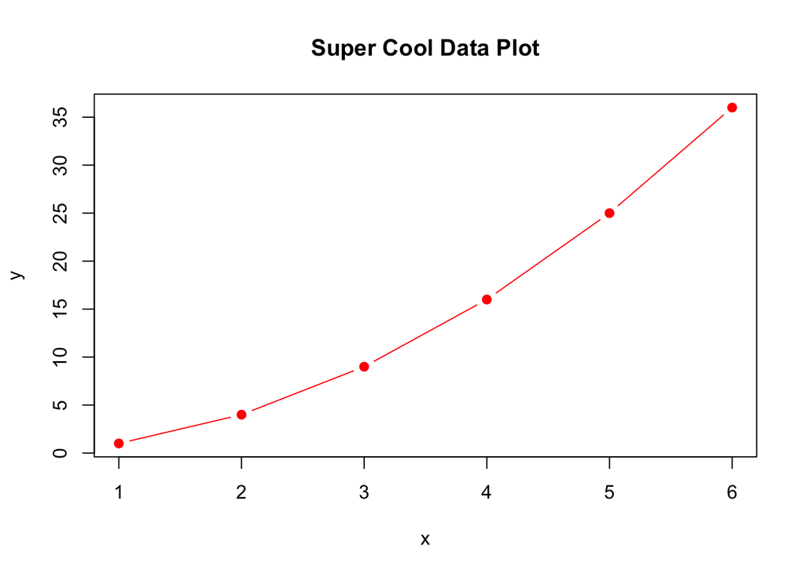

```r
plot(x,y,main="Super Cool Data Plot",type="b",pch=19,col="red")
```

#### Here we use a for-loop to add up the elements in a vector and find the average.

There are already functions in R to do this but knowing how to do it yourself is important

```r
x <-rnorm(1000,20,4) # 1,000 random elements from a N(20,4)

mysum <- 0
for (ii in 1:length(x)) {
    mysum <- mysum + x[ii]
}
avg <- mysum / length(x)

cat("The average of this vector is:",avg,"\n")
```

```
## The average of this vector is: 19.81978
```

```r
cat("The average of this vector is:",round(avg,2),"\n")
```

```
## The average of this vector is: 19.82
```

#### Given a vector find the smallest value without using the `min` function:

```r
set.seed(188)
x <- rnorm(1000) # 1,000 random elements from a N(20,4)

# Set the min to the first element of x. Unless we are very lucky then
# this will change as we walk through the vector
mymin <- x[1]
for (ii in 1:length(x)) {
    if (x[ii] < mymin) {
        mymin <- x[ii]
    }
}

mymin
```

```
## [1] -3.422185
```

```r
min(mymin) # The internal R function matches what we got
```

```
## [1] -3.422185
```

#### We can loop through data frames also. Let’s see if we can compute the mean of the MPG for all cars. Note that we use the `nrow()` function to get the number of rows to loop over.

```r
mpgsum <- 0
for (ii in 1:nrow(mtcars)) {
    mpgsum <- mpgsum + mtcars[ii,"mpg"]
}

mpgmean <- mpgsum/nrow(mtcars) # Divide the sum by the # of records

cat("Mean MPG for all cars is:",mpgmean,"\n")
```

```
## Mean MPG for all cars is: 20.09062
```

```r
mean(mtcars$mpg)
```

```
## [1] 20.09062
```

#### Remember the split command ? We can work with the output of that also. Relative to mtcars let’s split up the data frame by cylinder number, which is (4,6, or 8).

```r
mysplits <- split(mtcars, mtcars$cyl)

str(mysplits, max.level=1)
```

```
## List of 3
##  $ 4:'data.frame':   11 obs. of  11 variables:
##  $ 6:'data.frame':   7 obs. of  11 variables:
##  $ 8:'data.frame':   14 obs. of  11 variables:
```

```r
# We get back a list that contains 3 elements each of which has a data
# frame corresponding to the number of cylinders. We could summarize each
# of these data frame elements using a for loop

mysplits
```

```
## $`4`
##                 mpg cyl  disp  hp drat    wt  qsec vs am gear carb
## Datsun 710     22.8   4 108.0  93 3.85 2.320 18.61  1  1    4    1
## Merc 240D      24.4   4 146.7  62 3.69 3.190 20.00  1  0    4    2
## Merc 230       22.8   4 140.8  95 3.92 3.150 22.90  1  0    4    2
## Fiat 128       32.4   4  78.7  66 4.08 2.200 19.47  1  1    4    1
## Honda Civic    30.4   4  75.7  52 4.93 1.615 18.52  1  1    4    2
## Toyota Corolla 33.9   4  71.1  65 4.22 1.835 19.90  1  1    4    1
## Toyota Corona  21.5   4 120.1  97 3.70 2.465 20.01  1  0    3    1
## Fiat X1-9      27.3   4  79.0  66 4.08 1.935 18.90  1  1    4    1
## Porsche 914-2  26.0   4 120.3  91 4.43 2.140 16.70  0  1    5    2
## Lotus Europa   30.4   4  95.1 113 3.77 1.513 16.90  1  1    5    2
## Volvo 142E     21.4   4 121.0 109 4.11 2.780 18.60  1  1    4    2
##
## $`6`
##                 mpg cyl  disp  hp drat    wt  qsec vs am gear carb
## Mazda RX4      21.0   6 160.0 110 3.90 2.620 16.46  0  1    4    4
## Mazda RX4 Wag  21.0   6 160.0 110 3.90 2.875 17.02  0  1    4    4
## Hornet 4 Drive 21.4   6 258.0 110 3.08 3.215 19.44  1  0    3    1
## Valiant        18.1   6 225.0 105 2.76 3.460 20.22  1  0    3    1
## Merc 280       19.2   6 167.6 123 3.92 3.440 18.30  1  0    4    4
## Merc 280C      17.8   6 167.6 123 3.92 3.440 18.90  1  0    4    4
## Ferrari Dino   19.7   6 145.0 175 3.62 2.770 15.50  0  1    5    6
##
## $`8`
##                      mpg cyl  disp  hp drat    wt  qsec vs am gear carb
## Hornet Sportabout   18.7   8 360.0 175 3.15 3.440 17.02  0  0    3    2
## Duster 360          14.3   8 360.0 245 3.21 3.570 15.84  0  0    3    4
## Merc 450SE          16.4   8 275.8 180 3.07 4.070 17.40  0  0    3    3
## Merc 450SL          17.3   8 275.8 180 3.07 3.730 17.60  0  0    3    3
## Merc 450SLC         15.2   8 275.8 180 3.07 3.780 18.00  0  0    3    3
## Cadillac Fleetwood  10.4   8 472.0 205 2.93 5.250 17.98  0  0    3    4
## Lincoln Continental 10.4   8 460.0 215 3.00 5.424 17.82  0  0    3    4
## Chrysler Imperial   14.7   8 440.0 230 3.23 5.345 17.42  0  0    3    4
## Dodge Challenger    15.5   8 318.0 150 2.76 3.520 16.87  0  0    3    2
## AMC Javelin         15.2   8 304.0 150 3.15 3.435 17.30  0  0    3    2
## Camaro Z28          13.3   8 350.0 245 3.73 3.840 15.41  0  0    3    4
## Pontiac Firebird    19.2   8 400.0 175 3.08 3.845 17.05  0  0    3    2
## Ford Pantera L      15.8   8 351.0 264 4.22 3.170 14.50  0  1    5    4
## Maserati Bora       15.0   8 301.0 335 3.54 3.570 14.60  0  1    5    8
```

```r
for (ii in 1:length(mysplits)) {
     print(nrow(mysplits[[ii]]))
}
```

```
## [1] 11
## [1] 7
## [1] 14
```

```r
# This is equivalent to
sapply(mysplits, nrow)
```

```
##  4  6  8
## 11  7 14
```

```r
mysplit <- split(mtcars,mtcars$cyl)

for (ii in 1:length(mysplit)) {
     splitname <- names(mysplit[ii])
     cat("mean for",splitname,"cylinders is",mean(mysplit[[ii]]$mpg),"\n")
     ## cat function: concatenate and print
}
```

```
## mean for 4 cylinders is 26.66364
## mean for 6 cylinders is 19.74286
## mean for 8 cylinders is 15.1
```

```r
# This is basically equivalent to
sapply(mysplit, function(x) mean(x$mpg))
```

```
##        4        6        8
## 26.66364 19.74286 15.10000
```

#### Another example: looping over each split and pulling out only those cars with an manual transmission ? (am == 1)

```r
data(mtcars)

mysplit <- split(mtcars,mtcars$cyl)

mylist <- list() # Setup a blank list to contain the subset results
for (ii in 1:length(mysplit)) {
     mylist[[ii]] <- subset(mysplit[[ii]], am == 1)
}
mylist
```

```
## [[1]]
##                 mpg cyl  disp  hp drat    wt  qsec vs am gear carb
## Datsun 710     22.8   4 108.0  93 3.85 2.320 18.61  1  1    4    1
## Fiat 128       32.4   4  78.7  66 4.08 2.200 19.47  1  1    4    1
## Honda Civic    30.4   4  75.7  52 4.93 1.615 18.52  1  1    4    2
## Toyota Corolla 33.9   4  71.1  65 4.22 1.835 19.90  1  1    4    1
## Fiat X1-9      27.3   4  79.0  66 4.08 1.935 18.90  1  1    4    1
## Porsche 914-2  26.0   4 120.3  91 4.43 2.140 16.70  0  1    5    2
## Lotus Europa   30.4   4  95.1 113 3.77 1.513 16.90  1  1    5    2
## Volvo 142E     21.4   4 121.0 109 4.11 2.780 18.60  1  1    4    2
##
## [[2]]
##                mpg cyl disp  hp drat    wt  qsec vs am gear carb
## Mazda RX4     21.0   6  160 110 3.90 2.620 16.46  0  1    4    4
## Mazda RX4 Wag 21.0   6  160 110 3.90 2.875 17.02  0  1    4    4
## Ferrari Dino  19.7   6  145 175 3.62 2.770 15.50  0  1    5    6
##
## [[3]]
##                 mpg cyl disp  hp drat   wt qsec vs am gear carb
## Ford Pantera L 15.8   8  351 264 4.22 3.17 14.5  0  1    5    4
## Maserati Bora  15.0   8  301 335 3.54 3.57 14.6  0  1    5    8
```

```r
# Equivalent to:
lapply(mysplit, subset, am == 1)
```

```
## $`4`
##                 mpg cyl  disp  hp drat    wt  qsec vs am gear carb
## Datsun 710     22.8   4 108.0  93 3.85 2.320 18.61  1  1    4    1
## Fiat 128       32.4   4  78.7  66 4.08 2.200 19.47  1  1    4    1
## Honda Civic    30.4   4  75.7  52 4.93 1.615 18.52  1  1    4    2
## Toyota Corolla 33.9   4  71.1  65 4.22 1.835 19.90  1  1    4    1
## Fiat X1-9      27.3   4  79.0  66 4.08 1.935 18.90  1  1    4    1
## Porsche 914-2  26.0   4 120.3  91 4.43 2.140 16.70  0  1    5    2
## Lotus Europa   30.4   4  95.1 113 3.77 1.513 16.90  1  1    5    2
## Volvo 142E     21.4   4 121.0 109 4.11 2.780 18.60  1  1    4    2
##
## $`6`
##                mpg cyl disp  hp drat    wt  qsec vs am gear carb
## Mazda RX4     21.0   6  160 110 3.90 2.620 16.46  0  1    4    4
## Mazda RX4 Wag 21.0   6  160 110 3.90 2.875 17.02  0  1    4    4
## Ferrari Dino  19.7   6  145 175 3.62 2.770 15.50  0  1    5    6
##
## $`8`
##                 mpg cyl disp  hp drat   wt qsec vs am gear carb
## Ford Pantera L 15.8   8  351 264 4.22 3.17 14.5  0  1    5    4
## Maserati Bora  15.0   8  301 335 3.54 3.57 14.6  0  1    5    8
```

#### Let’s say we want to plot MPG vs. Weight for each cylinder group. Check it out:

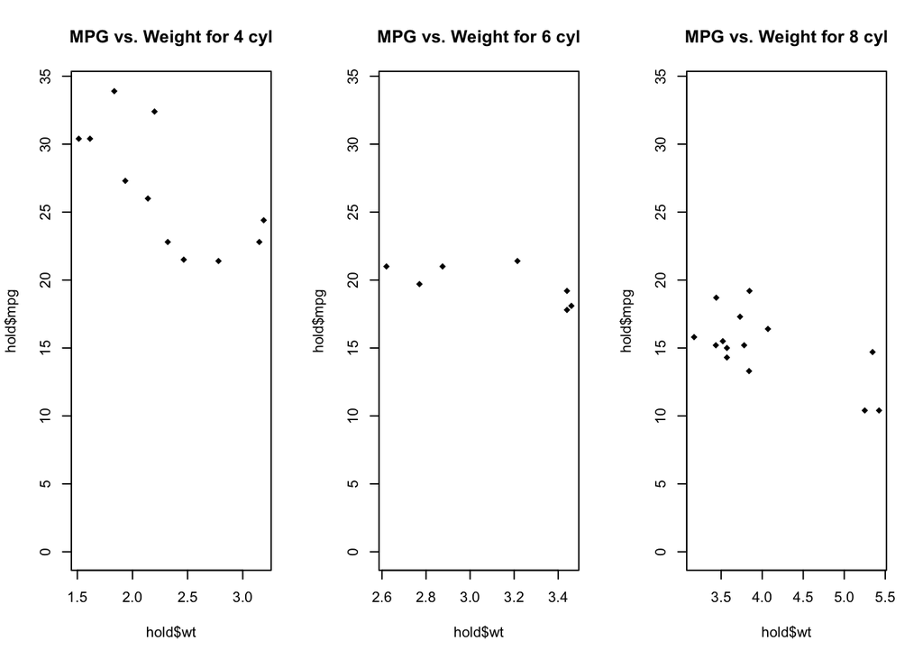

```r
mysplits <- split(mtcars, mtcars$cyl)

par(mfrow=c(1,3)) # This relates to plotting # show three plots at the same time

for (ii in 1:length(mysplits)) {
     hold <- mysplits[[ii]]
     plot(hold$wt, hold$mpg, pch = 18, main=paste("MPG vs. Weight for",
          names(mysplits[ii]), "cyl",sep=" "),ylim=c(0,34))
}
```

### Use `for` with matrices

#### We can generalize the for loop structure to matrices.

```r
set.seed(123)
mymat <- matrix(round(rnorm(6),2),3,2)
for (ii in 1:nrow(mymat)) {
     cat("The sum of row",ii,"is",sum(mymat[ii,]),"\n")
}
```

```
## The sum of row 1 is -0.49
## The sum of row 2 is -0.1
## The sum of row 3 is 3.28
```

### 2.2 `if` statement

#### This is an easy structure. It tests a logical expression, which results in either or a TRUE or FALSE condition, and, based on that, executes a specific block of code

```r
if (logical_expression) {
     do something
     ...
}

if (logical_expression) {
     do something
     ..
} else {
     do something else
     ...
}
```

#### A simple example

```r
x <- 3

is.numeric(x) # this is a logical example
```

```
## [1] TRUE
```

```r
if (is.numeric(x)) {
     print("x is a number")
}
```

```
## [1] "x is a number"
```

```r
if (x != 3) {
     print("x is not equal to 3")
} else {
     print("guess what ? x is in fact equal to 3")
}
```

```
## [1] "guess what ? x is in fact equal to 3"
```

#### Here is a more involved if statement that tests for several conditions. It uses the “else” keyword in addition to “if”. Note that an “if” statement does not require an “else” statement but an “else” statement requires a parent “if”" statement.

```r
some.num <- 3

if (some.num < 3) {
     print("Less than 3")
} else if (some.num > 3) {
     print("Greater than 3")
} else {
     print("Must be equal to 3")
}
```

```
## [1] "Must be equal to 3"
```

#### if/else statements show up a lot in functions. Checking for valid arguments is a common practice.

```r
x <- 4
y <- 5
if (!is.numeric(x) | !is.numeric(y)) {
     stop("I need numeric values to do this")
} else {
     if (x == y) {
          print("Equal")
     } else {
          print("Not equal")
     }
}
```

```
## [1] "Not equal"
```

### 2.3 `ifelse` statement

- **R supports a command called `ifelse` that is desgined to work specifcally on vectors.**
- **It works well for very large vectors. The format is `ifelse(test,yes,no)` where “test” is a logical expression to be evaluated.**
- **If it is `TRUE` then the action specified in the “yes” position will be executed. If the evaluated expression is `FALSE` then the action specified in the “no” position is executed.**

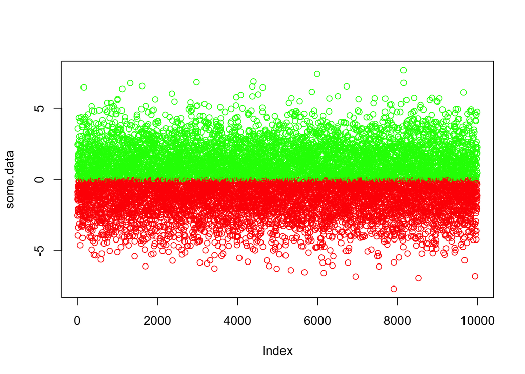

```r
some.data = rnorm(10000,0,2)
colors = ifelse(some.data < 0,"RED","GREEN")
plot(some.data,col=colors)
```

```r
# This would be the same as:
for (ii in 1:length(some.data)) {
     if (some.data[ii] < 0) {
          colors[ii] = "RED"
     } else {
          colors[ii] = "GREEN"
     }
}
```

#### We can use `ifelse` when we want to turn some continuous quantity within a data frame into a factor that we can then use to group by

```r
mtcars$rating <- ifelse(mtcars$mpg >= mean(mtcars$mpg), "blue", "red")

head(mtcars)
```

```
##                    mpg cyl disp  hp drat    wt  qsec vs am gear carb
## Mazda RX4         21.0   6  160 110 3.90 2.620 16.46  0  1    4    4
## Mazda RX4 Wag     21.0   6  160 110 3.90 2.875 17.02  0  1    4    4
## Datsun 710        22.8   4  108  93 3.85 2.320 18.61  1  1    4    1
## Hornet 4 Drive    21.4   6  258 110 3.08 3.215 19.44  1  0    3    1
## Hornet Sportabout 18.7   8  360 175 3.15 3.440 17.02  0  0    3    2
## Valiant           18.1   6  225 105 2.76 3.460 20.22  1  0    3    1
##                   rating
## Mazda RX4           blue
## Mazda RX4 Wag       blue
## Datsun 710          blue
## Hornet 4 Drive      blue
## Hornet Sportabout    red
## Valiant              red
```

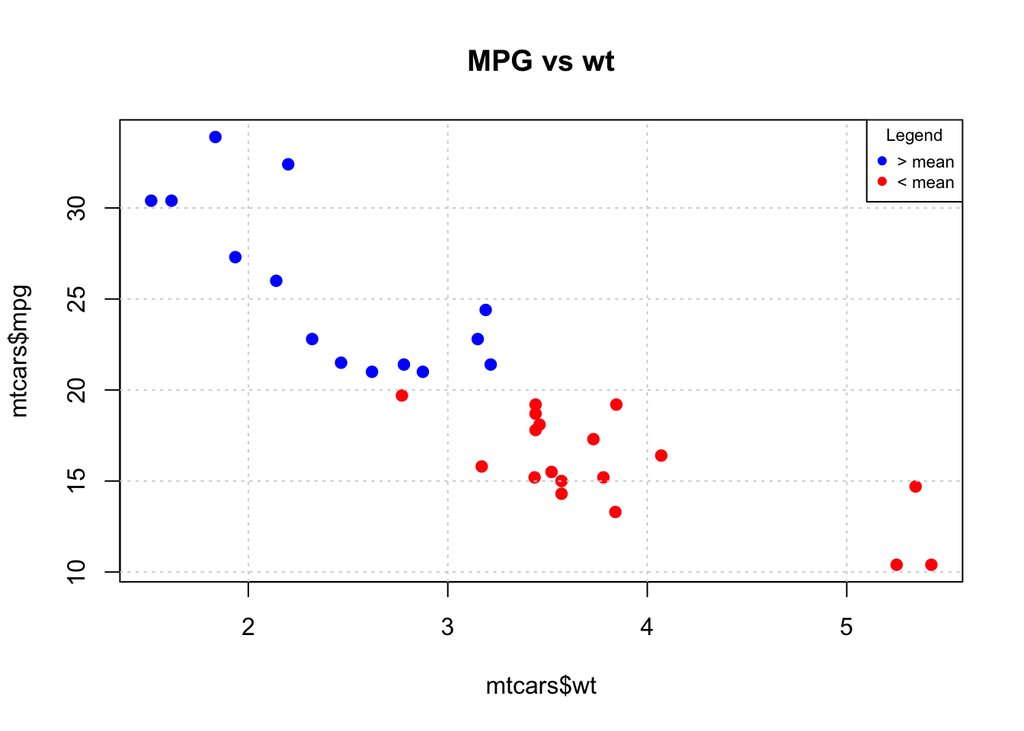

```r
plot(mtcars$mpg~mtcars$wt,col=mtcars$rating,pch=19, main="MPG vs wt")
grid()
legend("topright", c("> mean","< mean"), pch=19,
       col=c("blue","red"),title="Legend",cex=0.7)
```